# Lecture 19 Treatment Effect Methods and Review

Nick Huntington-Klein

2021-02-23

## Some Pointers

- Last time we talked about heterogeneous treatment effects and how our methods produce different averages of those effects
- But we don’t need to be limited to that!
- There are plenty of methods - many of them new - that let us estimate a *distribution* of treatment effects
- We won’t be going super far into detail with them, but I’ll mostly just be letting you know they exist and some pointers for looking further
- I’ll favor pointers to packages over papers, but if you look in the help files you’ll generally find paper citations

## Sorted Effects

- The *sorted effects* method uses covariates to look at variation in the treatment effect, and produces a distribution of treatment effects
- It also lets you see *who* is at each part of the distribution

```r
library(SortedEffects)
# Data on being denied for a mortgage.
data(mortgage)
# Save the formula to reuse later
fm <- deny ~ black + p_irat + hse_inc + ccred + mcred + pubrec + ltv_med +
           ltv_high + denpmi + selfemp + single + hischl
# spe() for "Sorted Partial Effects"
m <- spe(fm, data = mortgage,
         var = 'black', # black is the treatment variable
         method = 'logit',
         us = c(2:98)/100, # Get the distribution from the 2nd to 98th percentile
         b = 500, bc = TRUE) # Use bootstrapped SEs and bias-correction
```

## Sorted Effects

- See the distribution in the effect of black on being denied

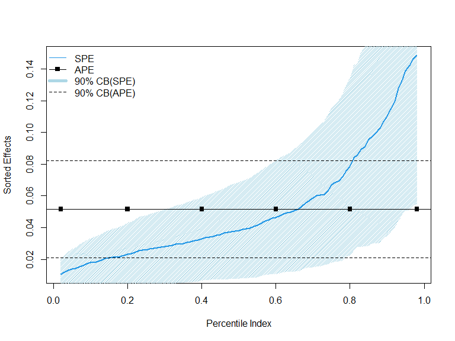

## Sorted Effects

- Who is most and least affected by the “treatment” of being black?

```r
t <- c("deny", "p_irat", "black", "hse_inc", "ccred", "mcred", "pubrec",
       "denpmi", "selfemp", "single", "hischl", "ltv_med", "ltv_high")
classify <- ca(fm, t = t, data = mortgage, var = 'black', method = 'logit',
               cl = 'both', # Get WHO the most and least are, not how different they are
               b = 500, bc = TRUE)
```

```
## Using 1 CPUs now.
```

```r
results <- summary(classify) %>%
  as_tibble() %>%
  mutate(Group = row.names(summary(classify)),
         Ratio = Most/Least) %>%
  select(Group, Most, Least, Ratio) %>%
  arrange(Ratio)
```

## Sorted Effects

| Group | Most | Least | Ratio |
| --- | --- | --- | --- |
| denpmi | 0.0061150 | 0.0476881 | 0.1282283 |
| hischl | 0.9321339 | 0.9961003 | 0.9357831 |
| hse_inc | 0.2805148 | 0.2103088 | 1.3338234 |
| mcred | 2.0154780 | 1.3658700 | 1.4756001 |
| p_irat | 0.3892355 | 0.2494585 | 1.5603213 |
| ccred | 4.7913548 | 1.2826253 | 3.7355843 |
| selfemp | 0.1734995 | 0.0422644 | 4.1051013 |
| deny | 0.4480543 | 0.0987269 | 4.5383183 |
| black | 0.3863966 | 0.0638143 | 6.0550127 |
| single | 0.6120107 | 0.0953380 | 6.4193784 |
| ltv_high | 0.1164659 | 0.0134757 | 8.6426423 |
| pubrec | 0.4616331 | 0.0510643 | 9.0402392 |
| ltv_med | 0.5977683 | 0.0539089 | 11.0884909 |

## Bayesian Hierarchical Modeling

- A very old method! But it works. An extension of random effects
- Instead of just letting the *constant* vary, let *any* coefficient vary, and give each its own function to vary over controls! Those controls can let the effect vary

$$Y = \beta_0 + \beta_1X + \varepsilon$$
$$\beta_0 = \gamma_{00} + \nu_{00}$$
$$\beta_1 = \gamma_{10} + \gamma_{11}W + \nu_{01}$$

- Terminology difference: “fixed effects” means “coefficients that don’t vary”

## Bayesian Hierarchical Modeling

```r
library(lme4)
# The whole thing would be super slow so for now let's just do a few effects
m <- lmer(deny ~ p_irat + hse_inc + ccred + mcred + pubrec + ltv_med +
           ltv_high + denpmi + selfemp + single + hischl +
       (single + hischl | black),
     data = mortgage)
```

## Bayesian Hierarchical Modeling (cut off)

```
## Linear mixed model fit by REML ['lmerMod']
## Formula: deny ~ p_irat + hse_inc + ccred + mcred + pubrec + ltv_med +
##     ltv_high + denpmi + selfemp + single + hischl + (single +
##     hischl | black)
##    Data: mortgage
##
## REML criterion at convergence: 722.8
##
## Scaled residuals:
##     Min      1Q  Median      3Q     Max
## -3.4138 -0.4242 -0.1776 -0.0076  3.9268
##
## Random effects:
##  Groups   Name        Variance  Std.Dev.  Corr
##  black    (Intercept) 3.803e-03 0.0616722
##           single      6.488e-07 0.0008055 -1.00
##           hischl      6.975e-05 0.0083517 -1.00  1.00
##  Residual             7.726e-02 0.2779482
## Number of obs: 2380, groups:  black, 2
##
## Fixed effects:
##              Estimate Std. Error t value
## (Intercept) -0.011466   0.069643  -0.165
## p_irat       0.449568   0.086586   5.192
## hse_inc     -0.072378   0.095866  -0.755
## ccred        0.031008   0.003673   8.441
## mcred        0.015003   0.011154   1.345
## pubrec       0.198644   0.023095   8.601
## ltv_med      0.032981   0.012356   2.669
## ltv_high     0.191246   0.033116   5.775
## denpmi       0.704414   0.041051  17.160
## selfemp      0.060240   0.017941   3.358
## single       0.034120   0.011944   2.857
## hischl      -0.134258   0.045705  -2.937
##
## Correlation of Fixed Effects:
##          (Intr) p_irat hse_nc ccred  mcred  pubrec ltv_md ltv_hg denpmi selfmp
## p_irat   -0.155
## hse_inc  -0.042 -0.781
## ccred    -0.090 -0.073  0.077
## mcred    -0.267  0.073 -0.106 -0.127
## pubrec    0.019 -0.054  0.012 -0.252  0.003
## ltv_med  -0.015 -0.063  0.020 -0.020 -0.150 -0.043
## ltv_high  0.031 -0.048  0.003 -0.019 -0.074 -0.044  0.180
## denpmi    0.017 -0.030  0.020 -0.006 -0.018 -0.058 -0.076 -0.073
## selfemp  -0.032 -0.078  0.064  0.012  0.040 -0.039  0.075  0.001  0.009
## single   -0.018  0.018 -0.043  0.022 -0.154  0.016  0.025 -0.018 -0.005  0.009
## hischl   -0.746  0.017  0.051  0.013  0.045 -0.001 -0.007 -0.033 -0.023 -0.002
##          single
## p_irat
## hse_inc
## ccred
## mcred
## pubrec
## ltv_med
## ltv_high
## denpmi
## selfemp
## single
## hischl   -0.058
## optimizer (nloptwrap) convergence code: 0 (OK)
## boundary (singular) fit: see ?isSingular
```

## Machine Learning

- The biggest contributions of machine learning to causal inference thus far have been in heterogeneous treatment effects
- (there are other things too, like matrix completion, which is way too complex to get into here)
- Allowing a zillion different things to vary is easy in machine learning!
- Note: machine learning tends to use “training” and “holdout” data. So estimate the model using a training subset, and then estimate your treatment effect distribution by sending your holdout data through that model

## LASSO and interactions

- LASSO is a “regularized regression” that does regression but doesn’t JUST minimize sum of squared errors, it also has a second goal of shrinking coefficients
- There are several forms of regularized regression. LASSO tends to set coefficeints to 0, i.e. chuck them out
- So… just interact treatment with everything and see what interactions are worth keeping!

## LASSO and interactions

- This is commonly applied in instrumental variables settings, where these interactions can improve first-stage power and ease the weak-instrument problem
- But can be applied elsewhere too to find variation in a treatment effect
- I won’t do a walkthrough here, but the package **glmnet** is typically used to estimate LASSO. See [this walkthrough](https://www.statology.org/lasso-regression-in-r/).

## Causal Forest

- A *random forest* is a prediction method. Take your data, go through every covariate you have, and every of each covariate, and split the data based on the split that minimizes sum of squared error
- Then do that again for each of the splits, and again and again. Each time only use a random subset of the variables
- Stop once the splits get too small
- *Causal forest* does the exact same thing except instead of minimizing the SSE, it *maximizes* the difference in causal effect between the splits
- i.e. it hunts for causal effect differences! You end up with an effect prediction for each individual

## Causal Forest

- **grf** does causal forest, and even has an IV version if you need an IV to identify

```r
library(grf)
mortgage <- mortgage %>% mutate(holdout = runif(n()) > .5)
holdout <- mortgage %>% filter(holdout)
training <- mortgage %>% filter(!holdout)
W = training %>% pull(black) %>% as.matrix()
X = training %>% select(p_irat, hse_inc, ccred, mcred, pubrec,
       denpmi, selfemp, single, hischl, ltv_med, ltv_high) %>% as.matrix()
Y = training %>% pull(deny) %>% as.matrix()
m <- causal_forest(X, Y, W, tune.parameters = 'alpha')
```

## Causal Forest

```r
X.holdout <- holdout %>% select(p_irat, hse_inc, ccred, mcred, pubrec,
       denpmi, selfemp, single, hischl, ltv_med, ltv_high) %>% as.matrix()
indiv_effects <- predict(m, X.holdout)
holdout <- holdout %>% mutate(effect = indiv_effects$predictions)
```

## Causal Forest

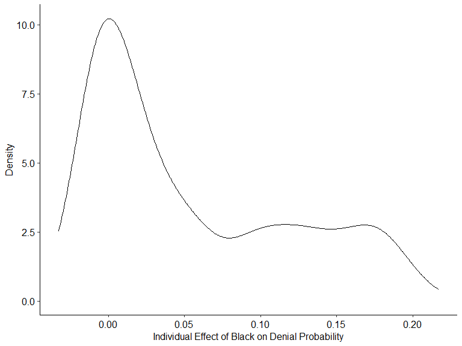

## Causal Forest

- Who is affected? Let’s do a similar test to what **SortedEffects** did (although we could look at it plenty of other ways)

| name | Bottom | Top | Ratio |
| --- | --- | --- | --- |
| selfemp | 0.2000000 | 0.1166667 | 0.5833333 |
| single | 0.4000000 | 0.3166667 | 0.7916667 |
| hischl | 0.9833333 | 0.9666667 | 0.9830508 |
| hse_inc | 0.2026083 | 0.2374417 | 1.1719245 |
| mcred | 1.5666667 | 1.9333333 | 1.2340426 |
| p_irat | 0.2522483 | 0.3322183 | 1.3170289 |
| black | 0.1333333 | 0.2333333 | 1.7500000 |
| ltv_high | 0.0333333 | 0.0833333 | 2.5000000 |
| ccred | 1.9500000 | 5.3333333 | 2.7350427 |
| pubrec | 0.0500000 | 0.2166667 | 4.3333333 |
| denpmi | 0.0000000 | 0.0333333 | Inf |
| ltv_med | 0.0000000 | 0.3333333 | Inf |

## Treatment Effect Methods

- Anyway, there’s some stuff for you to check out!
- Obviously there are zillions of causal-inference methods we don’t have time to cover
- Bartik instruments, matrix completion, causal discovery, and so on and so on and so on
- Consider this a good starting place

## Exam Review

- Just a reminder of some stuff we’ve covered

## Fixed Effects

- If we have data where we observe the same people over and over, we can implement *fixed effects* by controlling for *individual*
- This accounts for everything that’s constant within individual. If, for example, “individual” was city, that would include geography, state, founding year, etc.
- Doesn’t account for things that vary within individual over time, like `Laws`

## Difference-in-Difference

- Difference-in-Difference applies when you have a group that you can observe both before and after the policy
- You worry that `time` is a confounder, but you can’t control for it
- Unless you add a control group that DIDN’T get the policy
- We must be careful to check that parallel trends holds

## Difference-in-Difference

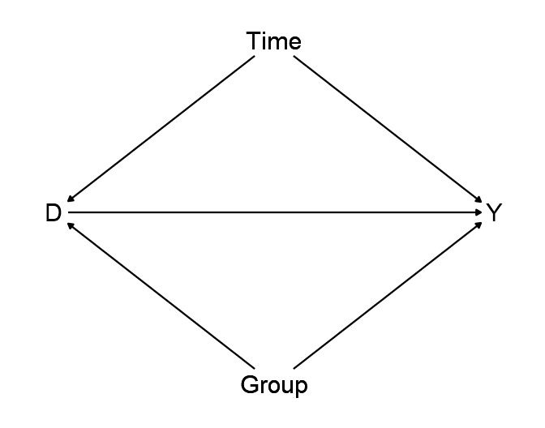

## Difference-in-Difference

- Get the before-after difference for both groups
- Then subtract out the difference for the control

```r
diddata <- tibble(Group=c(rep("C",2500),rep("T",2500)),
                  Time=rep(c(rep("Before",1250),rep("After",1250)),2)) %>%
  mutate(Treated = (Group == "T") & Time == "After") %>%
  mutate(Y = 2*(Group == "T") + 1.5*(Time == "After") + 3*Treated + rnorm(5000))
did <- diddata %>% group_by(Group,Time) %>% summarize(Y = mean(Y))
before.after.control <- did$Y[1] - did$Y[2]
before.after.treated <- did$Y[3] - did$Y[4]
did.effect <- before.after.treated - before.after.control
did.effect
```

```
## [1] 2.936178
```

```r
m <- feols(Y ~ Treated | Group + Time, data = diddata)
coef(m)
```

```
## TreatedTRUE
##    2.936178
```

## Regression Discontinuity

- If we have a treatment `D` that is assigned based on a cutoff in a running variable, we can use regression discontinuity
- Focus right around the cutoff and compare above-cutoff to below-cutoff
- We’ve isolated a great set of treatment/control groups because in this area it’s basically random whether you’re above or below the cutoff

## Regression Discontinuity

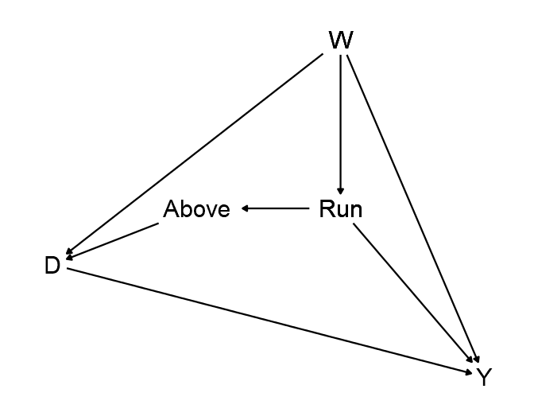

## Regression Discontinuity

- Estimate by fitting a line that jumps at the cutoff and estimating the jump
- Use local regression and bandwidths to avoid being affected by far-away observations
- “Fuzzy” designs where treatment only jumps partially scale the effect using IV

## Regression Discontinuity

- Expressed well in graphs! Treatment should jump at cutoff. If not perfectly from 0% to 100%, use IV too

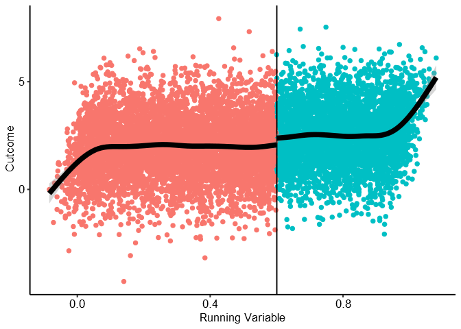

## Regression Discontinuity

- Variables other than `Y` and treatment shouldn’t jump at cutoff - they should be balanced

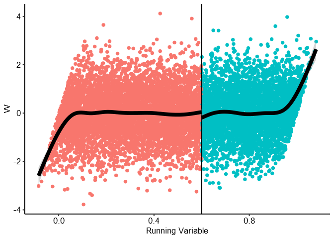

## Instrumental Variables

- An instrumental variable affects treatment (relevant) but has no back doors itself or paths to $Y$ except through $X$ (valid)
- We move the no-open-back-doors assumption to the IV rather than the treatment
- We isolate JUST the variation that comes from `Z`. No back doors in that variation! We have a causal effect
- Can conceptually think of it as (or literally apply it to) an experiment where randomization doesn’t work perfectly

## Instrumental Variables

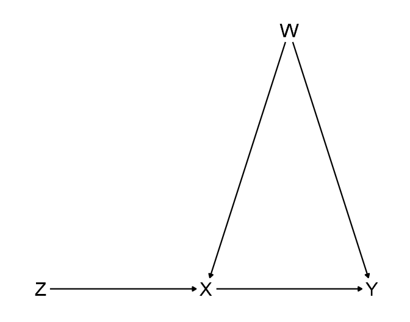

## Treatment Effects

- There isn’t *a* treatment effect. They vary across time, space, individual
- Our methods give us averages - ATE (experiment), ATT (DID), LATE (IV, RDD), variance-weighted (regression w/ controls), etc.
- We must pay close attention to what our design *and estimator* gives us

## That’s it!

- In a very condensed way, that’s the material we covered!
- I recommend looking back over slides, notes, homeworks